# ML_MateuszJalocha

Mateusz Jalocha

26 stycznia 2019

## 1. Wstęp

Rynek zakładów bukmacherskich w samej Polsce jest wart około 5 mld zł, a setki tysięcy “graczy” zmaga się z problemem jak obstawiać tak, aby zmaksymalizować zyski. Niniejszy projekt dotyczy meczów piłkarskich, a dokładniej rzecz biorąc, meczów Szkockiej Premier League, czyli najwyższej ligi rozgrywkowej w tym kraju. W związku z dużą liczbą zmiennych wpływających na wynik meczu oraz tym jak nieprzewidywalnym sportem jest piłka nożna, skomponowanie dobrego modelu jest niesamowicie trudne. Postaram się w tej stworzyć modele przy pomocy czterech metod: KNN, Naiwny Klasyfikator Bayesa, Drzewo Decyzyjne oraz Random Forest, za pomocą których będzie możliwe przewidywanie czy gospodarz zwycięży w tym meczu, w przeciwnym przypadku mecz wygra gość lub padnie remis. Projekt jest ciekawy o tyle, że w przypadku dobrych wyników, modele będą mogły wspomagać podejmowanie decyzji dotyczącej zakładów bukmacherskich. W pracy w miejscach, które uznałem za zawierające ciekawy kod znajdują się przyciski code, po naciśnięciu których naciśnięciu się ukaże.

## 2. Dane

Dane w większości zostały pobrane ze strony http://www.football-data.co.uk/scotlandm.php i dotyczą sezonu 2017/2018 oraz część została zdobyta przy pomocy webscrappingu. W podstawowej formie nie nadawały się do tworzenia na ich podstawie modeli, w związku z czym zostały poddane obróbce, która została zaprezentowana poniżej. Ponadto ze zmiennych zostały usunięte zmienne dotyczące kursów bukmacherskich, aby badanie opierało się tylko na statystykach piłkarskich. W zbiorze danych nie występują brakujące obserwacje.

### 2.1 Webscrapping

W celu zwiększenia liczby zmiennych ze strony https://www.fifaindex.com/pl/teams/fifa18_278/?league=50&order=desc zostały wydobyte informacje dotyczące średniej oceny ogólnej każdego zespołu występujującego w Szkockiej Premier League w sezonie 2017/2018. Nazwy zespołów zostały dostosowane do tych znajdujących się w sciągniętym pliku z pozostałymi zmiennymi. Pomimo, że są to tylko liczby w grze to jednak są stworzone przez ekspertów i przyczyniają się do poprawy jakości modeli.

```r
####Data preparation####
data <- read.csv("ScotPrem.csv", dec = ",", sep = ";")

#Create a vector with information if home teams shoot
homeScore <- data$FTHomeGoals

#Create vector with team names
teams <- as.character(unlist(unique(data$HomeTeam)))

#Read html
url <- 'https://www.fifaindex.com/pl/teams/fifa18_278/?league=50&order=desc'
webpage <- read_html(url)

#Select overall's
rating_data_html <- html_nodes(webpage,'td:nth-child(7) .rating')
team_names_html <- html_nodes(webpage, 'td+ td .link-team')

#Convert html to text
rating_data <- html_text(rating_data_html)
rating_data <- as.numeric(unlist(rating_data))

#Correct the team names from fifaindex webpage
team_names <- html_text(team_names_html)
team_names <- gsub(' [A-z ]*', '' , team_names)
team_names[2] <- "Rangers"
team_names[8] <- "St Johnstone"
team_names[7] <- "Ross County"
team_names[4] <- "Hearts"

#Assign overall to list
overall <- list()
for( i in 1:length(team_names)){
  overall[[team_names[i]]] <- rating_data[i]
}
```

### 2.2 Podstawowa forma danych

Jak już zostało wcześniej wspomniane zmienne dotyczące kursów bukmacherskich zostały usunięte, a dane po tym zabiegu prezentują się następująco:

| HomeTeam | AwayTeam | FTHomeGoals | FTAwayGoals | FTresults | HTHomeGoals | HTAwayGoals | HalfTimeRes | Referee | HomeShots | AwayShots | HomeShotsTarget | AwayShotsTarget | HomeFouls | AwayFouls | HomeCorners | AwayCorners | HomeYellow | AwayYellow | HomeRed | AwayRed |
| --- | --- | --- | --- | --- | --- | --- | --- | --- | --- | --- | --- | --- | --- | --- | --- | --- | --- | --- | --- | --- |
| Celtic | Hearts | 4 | 1 | H | 1 | 0 | H | K Clancy | 17 | 4 | 7 | 3 | 9 | 21 | 9 | 5 | 1 | 3 | 0 | 0 |
| Dundee | Ross County | 1 | 2 | A | 0 | 1 | A | W Collum | 13 | 14 | 6 | 5 | 14 | 8 | 15 | 5 | 1 | 2 | 0 | 0 |
| Hibernian | Partick | 3 | 1 | H | 2 | 1 | H | N Walsh | 12 | 6 | 6 | 3 | 13 | 19 | 3 | 4 | 2 | 3 | 0 | 0 |
| Kilmarnock | St Johnstone | 1 | 2 | A | 0 | 1 | A | S McLean | 12 | 8 | 4 | 2 | 12 | 16 | 1 | 10 | 1 | 4 | 0 | 0 |
| Aberdeen | Hamilton | 2 | 0 | H | 1 | 0 | H | E Anderson | 17 | 5 | 7 | 3 | 10 | 17 | 3 | 2 | 1 | 3 | 0 | 1 |
| Motherwell | Rangers | 1 | 2 | A | 1 | 1 | D | B Madden | 10 | 15 | 2 | 3 | 17 | 17 | 7 | 5 | 4 | 2 | 0 | 0 |

W związku z dużą liczbą występujących podobnych zmiennych, różniących się tylko tym czy dotyczą drużyny domowej (Home) czy wyjazdowej (Away), opis został skrócony zawierając w nazwach niektórych zmiennych (Home/Away) co oznacza, że występuje taka zmienna dla drużyny gospodarzy oraz gości. Używane zmienne to:

- **(Home/Away)Team** - Nazwa drużyny
- **FT(Home/Away)Goals** - Liczba strzelonych goli w meczu
- **FTRes** - Wynik meczu (H - wygrana drużyny domowej, D - remis, A - wygrana drużyny wyjazdowej)
- **HT(Home/Away)Goals** - Liczba strzelonych bramek do połowy meczu
- **HalfTimeRes** - Wynik meczu do połowy (H - wygrana drużyny domowej, D - remis, A - wygrana drużyny wyjazdowej)
- **Referee** - Sędzia w meczu
- **(Home/Away)Shots** - Liczba oddanych strzałów w meczu
- **(Home/Away)ShotsTarget** - Liczba oddanych celnych strzałów w meczu
- **(Home/Away)Fouls** - Liczba popełnionych fauli w meczu
- **(Home/Away)Corners** - Liczba rzutów rożnych w meczu
- **(Home/Away)Yellow** - Liczba otrzymanych żółtych kartek w meczu
- **(Home/Away)Red** - Liczba otrzymanych czerwonych kartek w meczu

### 2.3 Przygotowywanie nowych zmiennych

Niestety większość zmiennych nie nadaje się do konstruowania modelu przewidującego czy gospodarz odniesie zwycięstwo, jednak mogą one posłużyć do stworzenia nowych i użytecznych. Na początku zostały odrzucone zmienne, które mają znikomy wpływ na to czy gospodarz odniesie zwycięstwo, takie jak: **HT(Home/Away)Goals**, **HalfTimeRes**, **Referee**, **(Home/Away)Yellow**, **(Home/Away)Red**. A na podstawie pozostałych zmiennych zostały stworzone nowe, tabela danych po obróbce prezentuje się następująco:

```r
##Calculation of how many points the teams had when they entered the matches

#Total number of corners in the match
corners <- data$HomeCorners + data$AwayCorners
#Create lists for the number of points and the information which side won the match
homeOrAway <- list()
points <- list()

#Calculation of the number of points of the teams entering the matches
for(i in 1:length(teams)) {
  teams_data <- data[which(data$HomeTeam == teams[i] | data$AwayTeam == teams[i]),]
  match_points <- 0
  sumcia <- 0
  homeOrAway_vec <- vector()
  for(j in 1:nrow(teams_data)) {
    results <- teams_data[j,c(3,4,7)]

    if(results$HomeTeam == teams[i] & results$FTresults == "H") {
      sumcia <- match_points[length(match_points)] + 3
      match_points[j] <- sumcia
      homeOrAway_vec[j] <- "H"
    }
    if(results$HomeTeam == teams[i] & results$FTresults == "D") {
      sumcia <- match_points[length(match_points)] + 1
      match_points[j] <- sumcia
      homeOrAway_vec[j] <- "H"
    }
    if(results$HomeTeam == teams[i] & results$FTresults == "A") {
      sumcia <- match_points[length(match_points)] + 0
      match_points[j] <- sumcia
      homeOrAway_vec[j] <- "H"
    }
    if(results$AwayTeam == teams[i] & results$FTresults == "A") {
      sumcia <- match_points[length(match_points)] + 3
      match_points[j] <- sumcia
      homeOrAway_vec[j] <- "A"
    }
    if(results$AwayTeam == teams[i] & results$FTresults == "D") {
      sumcia <- match_points[length(match_points)] + 1
      match_points[j] <- sumcia
      homeOrAway_vec[j] <- "A"
    }
    if(results$AwayTeam == teams[i] & results$FTresults == "H") {
      sumcia <- match_points[length(match_points)] + 0
      match_points[j] <- sumcia
      homeOrAway_vec[j] <- "A"
    }
  }
  points[[teams[i]]] <- c(0,match_points[-length(match_points)])
  homeOrAway[[teams[i]]] <- homeOrAway_vec
}

#Save match result as a binary variable
match_results <- as.character(unlist(data$FTresults))

match_results[match_results == "H"] <- 1
match_results[match_results != 1] <- 0

match_results <- as.numeric(match_results)

data$FTresults <- match_results

#Add overall to dataset
data <- data.frame(data, HomeOverall = rep(1,nrow(data)),AwayOverall = rep(2,nrow(data)))

for(i in 1:length(teams)) {
  data[which(data$HomeTeam==teams[i]),24] <- overall[[teams[i]]]
  data[which(data$AwayTeam==teams[i]),25] <- overall[[teams[i]]]
}

#Calculate averages for guest and host teams for variables such as number of shoots, corners, yellow cars, etc.
avgFTHGoals <- avgFunction(data, teams, 5, "home")
avgHomeLost <- avgFunction(data, teams, 6, "home")
avgFTAGoals <- avgFunction(data, teams, 6, "away")
avgAwayLost <- avgFunction(data, teams, 5, "away")
avgHTShots <- avgFunction(data, teams, 12, "home")
avgATShots <- avgFunction(data, teams, 13, "away")
avgHTTarget <- avgFunction(data, teams, 14, "home")
avgATTarget <- avgFunction(data, teams, 15, "away")
avgHomeFouls <- avgFunction(data, teams, 16, "home")
avgAwayFouls <- avgFunction(data, teams, 17, "away")
avgHTCorners <- avgFunction(data, teams, 18, "home")
avgATCorners <- avgFunction(data, teams, 19, "away")
avgHomeYellow <- avgFunction(data, teams, 20, "home")
avgAwayYellow <- avgFunction(data, teams, 21, "away")
avgHomeRed <- avgFunction(data, teams, 22, "home")
avgAwayRed <- avgFunction(data, teams, 23, "away")


#Assign new variables to dataset
for(i in 1:length(teams)){
  #Goals
  data[which(data$HomeTeam == teams[i]),5] <- avgFTHGoals[[teams[i]]]
  data[which(data$HomeTeam == teams[i]),8] <- avgHomeLost[[teams[i]]]
  data[which(data$AwayTeam == teams[i]),6] <- avgFTAGoals[[teams[i]]]
  data[which(data$AwayTeam == teams[i]),9] <- avgAwayLost[[teams[i]]]

  #Shots
  data[which(data$HomeTeam == teams[i]),12] <- avgHTShots[[teams[i]]]
  data[which(data$AwayTeam == teams[i]),13] <- avgATShots[[teams[i]]]
  data[which(data$HomeTeam == teams[i]),14] <- avgHTTarget[[teams[i]]]
  data[which(data$AwayTeam == teams[i]),15] <- avgATTarget[[teams[i]]]

  #Fouls
  data[which(data$HomeTeam == teams[i]),16] <- avgHomeFouls[[teams[i]]]
  data[which(data$AwayTeam == teams[i]),17] <- avgAwayFouls[[teams[i]]]

  #Corners
  data[which(data$HomeTeam == teams[i]),18] <- avgHTCorners[[teams[i]]]
  data[which(data$AwayTeam == teams[i]),19] <- avgATCorners[[teams[i]]]

  #Cards
  data[which(data$HomeTeam == teams[i]),20] <- avgHomeYellow[[teams[i]]]
  data[which(data$AwayTeam == teams[i]),21] <- avgAwayYellow[[teams[i]]]
  data[which(data$HomeTeam == teams[i]),22] <- avgHomeRed[[teams[i]]]
  data[which(data$AwayTeam == teams[i]),23] <- avgAwayRed[[teams[i]]]
}

#Add number of points that the teams had when they played a match to dataset
data <- cbind(data, HomePoint = rep(1, nrow(data)), AwayPoint = rep(2,nrow(data)))
for(i in 1:length(teams)) {
  data[which(data$HomeTeam==teams[i]),26] <- points[[teams[i]]][which(homeOrAway[[teams[i]]] == "H")]
  data[which(data$AwayTeam==teams[i]),27] <- points[[teams[i]]][which(homeOrAway[[teams[i]]] == "A")]
}

#Create data frame with all variables (due to a lack of points, the first two rounds were not taken into account)
data <- data[-c(1:12),]
data <- data[,c(3,4,5,6,7,8,9,12,13,14,15,16,17,18,19,20,21,24,25,26,27)]
colnames(data) <- c("HomeTeam", "AwayTeam", "HomeGoals","AwayGoals", "Result", "HomeLost", "AwayLost","HomeShots","AwayShots",
                    "HomeTarget", "AwayTarget", "HomeFouls", "AwayFouls", "HomeCorners", "AwayCorners","HomeYellow", "AwayYellow",
                    "HomeOverall", "AwayOverall","HomePoints", "AwayPoints")

data <- data.frame(HomeTeam = data$HomeTeam, AwayTeam = data$AwayTeam, Result = data$Result,HomeScore = homeScore[-c(1:12)], AVGGoals = data$HomeGoals - data$AwayGoals, AVGLost = data$HomeLost - data$AwayLost,
                   AVGShots = data$HomeShots - data$AwayShots, AVGTarget = data$HomeTarget - data$AwayTarget,
                   AVGCorners = data$HomeCorners - data$AwayCorners, AVGFouls = data$HomeFouls - data$AwayFouls,
                   Overall = (data$HomeOverall/data$AwayOverall) - 1, PointsDiff = data$HomePoints-data$AwayPoints)


data[which(data$HomeScore >0 ),4] <- 1
data <- data[,-4]

kable(head(data), "html") %>% kable_styling("striped")
```

| HomeTeam | AwayTeam | Result | AVGGoals | AVGLost | AVGShots | AVGTarget | AVGCorners | AVGFouls | Overall | PointsDiff |
| --- | --- | --- | --- | --- | --- | --- | --- | --- | --- | --- |
| Aberdeen | Dundee | 1 | 2.0 | -3.0 | 6.0 | 3.0 | -4.0 | -9.0 | 0.0952381 | 6 |
| Hibernian | Hamilton | 0 | 3.0 | -1.0 | 7.0 | 3.0 | 1.0 | -4.0 | 0.0819672 | 3 |
| Kilmarnock | Celtic | 0 | -0.5 | 1.5 | -7.0 | -2.5 | -8.5 | 11.5 | -0.1081081 | -6 |
| Motherwell | Ross County | 1 | -1.0 | 1.0 | -4.0 | -3.0 | 2.0 | 9.0 | -0.0153846 | -3 |
| Rangers | Hearts | 0 | 1.0 | 1.0 | 5.5 | -1.5 | 1.0 | -4.0 | 0.0597015 | 0 |
| St Johnstone | Partick | 1 | 3.0 | -2.0 | 3.0 | 4.0 | 3.0 | -10.0 | 0.0000000 | 6 |

```r
data$Corners <- corners[13:228]
```

Dla osób interesujących się piłką nożną jasnym jest, że często dochodzi do sytuacji, że dana drużyna inaczej radzi sobie na wyjeĹşdzie, a inaczej na swoim stadionie. W związku z czym przygotowane zmienne opierają się na średnich statystykach jakie dana drużyna posiada na wyjeĹşdzie lub jako gospodarz, w zależności od tego gdzie gra mecz. Jeśli drużyna “A” gra jako gospodarz i “B” jako gość, to do wyliczenia zmiennych były brane odpowiednio średnie statystyki drużyny “A” w roli gospodarza oraz średnie statystyki drużyny “B” w roli drużyny wyjazdowej. Większość zmiennych opiera się na różnicy pomiędzy średnimi statystykami grających drużyn, w przypadku kiedy wartość jest większa od 0 oznacza to, że drużyna gospodarzy średnio więcej doświadcza pewnego zdarzenia w roli drużyny domowej, aniżeli drużyna wyjazdowa w roli gościa. Wyjątkami są zmienne: Overall - ile razy większą ocenę ogólną posiada drużyna gospodarza; PointsDiff - ile więcej punktów posiada gospodarz niż gość w tym meczu. Ogólny opis:

- **(Home/Away)Team** - Nazwa drużyny
- **Result** - Wynik meczu (1 - wygrana gospodarzy, 0 - przegrana gospodarzy lub remis)
- **AVGGoals** - Różnica w średniej liczbie strzelonych dotychczas bramek na mecz przez obie drużyny. Jeśli gospodarz będzie strzelał średnio więcej bramek na mecz w roli gospodarza niż gość w roli gościa, to szansa na wygranie meczu przez drużyne domową powinna wzrosnąć, w przeciwnym przypadku zmaleć
- **AVGLost** - Różnica w średniej liczbie traconych dotychczas bramek na mecz przez obie drużyny. Jeśli gospodarz będzie tracił średnio więcej bramek na mecz w roli gospodarza niż gość w roli gościa, to szansa na wygranie meczu przez drużyne domową powinna zmaleć, w przeciwnym przypadku wzrosnąć
- **AVGShots** - Różnica w średniej liczbie oddanych dotychczas strzałów na mecz przez obie drużyny. Jeśli gospodarz będzie oddawał średnio więcej strzałów na mecz w roli gospodarza niż gość w roli gościa, to szansa na strzelenie bramki przez gospodarza powinna wzrosnąć, a co za tym idzie, szansa na wygranie meczu przez drużyne domową również powinno wzrosnąć, w przeciwnym przypadku zmaleć.
- **AVGTarget** - Różnica w średniej liczbie oddanych dotychczas celnych strzałów na mecz przez obie drużyny. Jeśli gospodarz będzie oddawał średnio więcej celnych strzałów na mecz w roli gospodarza niż gość w roli gościa, to szansa na strzelenie bramki przez gospodarza powinna wzrosnąć, a co za tym idzie, szansa na wygranie meczu przez drużyne domową również powinno wzrosnąć, w przeciwnym przypadku zmaleć.
- **AVGCorners** - Różnica w średniej liczbie posiadanych dotychczas rzutów rożnych na mecz przez obie drużyny. Jeśli gospodarz będzie posiadał średnio więcej rzutów rożnych na mecz w roli gospodarza niż gość w roli gościa, to szansa na strzelenie bramki przez gospodarza powinna wzrosnąć w związku z większą ilością sytuacji podbramkowych, a co za tym idzie, szansa na wygranie meczu przez drużyne domową również powinna wzrosnąć, w przeciwnym przypadku zmaleć.
- **AVGFouls** - Różnica w średniej liczbie popełnianych dotychczas fauli na mecz przez obie drużyny Jeśli gospodarz będzie popełniał średnio więcej fauli na mecz w roli gospodarza niż gość w roli gościa, to szansa na strzelenie bramki przez gospodarza powinna zmaleć w związku z większą ilością sytuacji, w których może on stracić zawodnika przez wykartkowanie lub rośnie szansa na to, że drużyna przeciwna będzie mogła oddać strzał bezpośredni z wolnego, a co za tym idzie, szansa na wygranie meczu przez drużyne domową również powinna zmaleć, w przeciwnym przypadku wzrosnąć.
- **Overall** - Ile razy więcej oceny ogólnej posiada drużyna przystępująca do meczu w roli gospodarza niż przeciwna. Im lepszy będzie zespół występujący w roli gospodarza tym większą powinien posiadać szansę na wygranie meczu.
- **PointsDiff** - Ile więcej punktów posiada gospodarz niż gość w tym meczu. Im lepiej będzie radzić sobie drużyna domowa w roli gospodarza niż wyjazdowa w gościa tym większą szanse na odniesienie zwycięstwa powinna mieć.

## 3. Eksploracja zmiennych

Eksploracja zmiennych została rozpoczęta od sprawdzenia liczności dla meczów, w których wygrała drużyna gospodarzy i pozostałych:

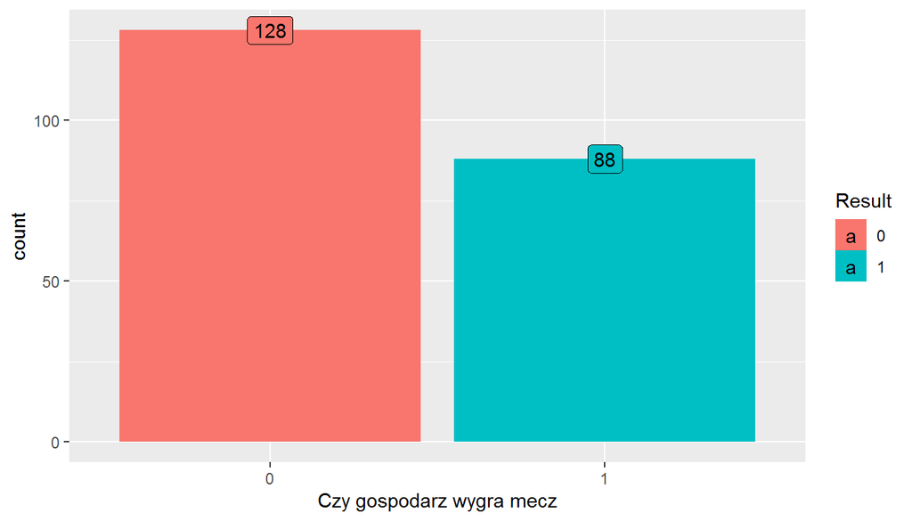

W 40% meczów zwycięstwo odniosła drużyna grająca u siebie, co nie jest najlepszym wynikiem, jednak nadal pozwala na osiągnięcie ciekawych zysków przy obstawianiu na gospodarzy w zakładach bukmacherskich jeśli wyniki modelu będą na przyzwoitym poziomie.

### 3.1 Podstawowe statystyki

Podstawowe statystyki dotyczące zmiennych wyglądają następująco:

| variable | mean | sd | median | min | max |
| --- | --- | --- | --- | --- | --- |
| AVGGoals | 0.11 | 0.82 | 0.14 | -3 | 3 |
| AVGLost | -0.11 | 0.7 | -0.11 | -3 | 1.55 |
| AVGShots | 0.7 | 4.88 | 0.65 | -14.5 | 14.25 |
| AVGTarget | 0.42 | 1.97 | 0.2 | -7.5 | 6.25 |
| AVGCorners | 0.33 | 2.38 | 0.35 | -8.5 | 10 |
| AVGFouls | -0.43 | 3.62 | -0.34 | -11.5 | 15 |
| Overall | 0 | 0.07 | 0 | -0.18 | 0.21 |
| PointsDiff | -0.11 | 13.7 | 0 | -42 | 46 |
| Corners | 10.25 | 3.38 | 10 | 3 | 20 |

### 3.2 Wykresy pudełkowe

Koljenym etapem jest przyjrzenie się czy różnią się mediany w poszczególnych zmiennych oraz kwartyle i odchylenia w zależności od rezultatu:

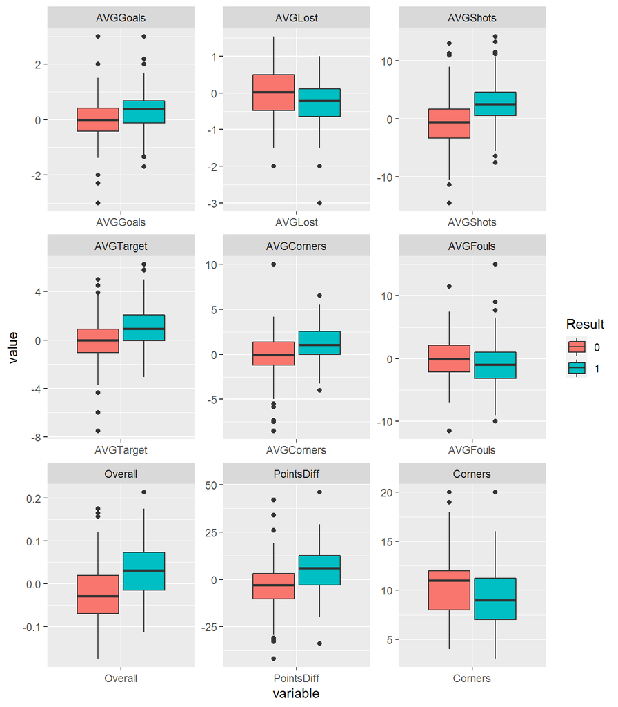

Występują obserwacje odstające jednak ze względu na to, aby nie tracić zmiennych oraz ze względu na to, że nie są w większości drastycznie odstające w tym przypadku zostaną zachowane. Jak można zauważyć na wykresach największe różnice występują przy zmiennych: AVGShots oraz Overall, w związku z czym powinny determinować w sposób jeden z lepszych przy tym zbiorze danych. Natomiast pudełka z wąsami na wykresach zmiennych takich jak: AVGGoals i AVGFouls są najbardziej podobne do siebie w związku z czym powinny determinować w sposób jeden z gorszych dla takich zmiennych.

### 3.3 Macierz korelacji

Ostatecznie przyjrzymy się macierzy korelacji:

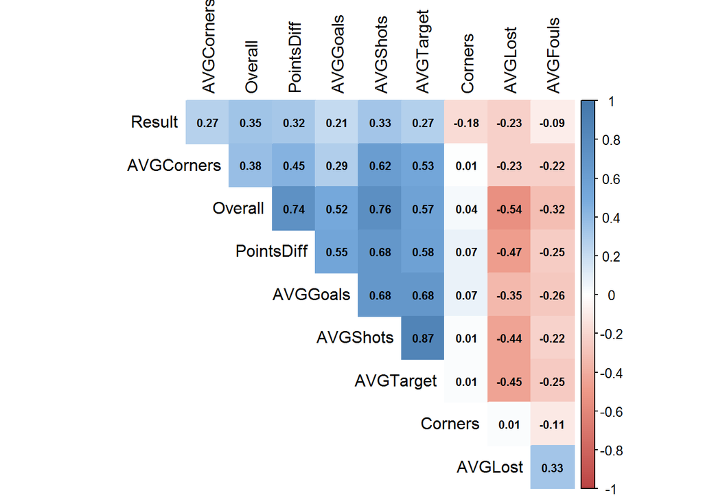

```r
#Correlation coefficient
corrCoef <- cor(data[,-c(1,2)])

col <- colorRampPalette(c("#BB4444", "#EE9988", "#FFFFFF", "#77AADD", "#4477AA"))
corrplot(corrCoef, method = "color", col = col(200),
         type = "upper", order = "hclust", number.cex = .7,
         addCoef.col = "black", # Add coefficient of correlation
         tl.col = "black", tl.srt = 90, # Text label color and rotation
         # Combine with significance
          sig.level = 0.01, insig = "blank",
         # hide correlation coefficient on the principal diagonal
         diag = FALSE)
```

Jak można zauważyć korelacje nie są satysfakcjonujące, ze zmienną Result, pozostałe zmienne mają umiarkowaną korelacje, natomiast pomiędzy zmiennymi objaśniającymi jest ona w wielu przypadkach duża. Występują trzy korelacje powyżej 0.7 co może wpłynąć na metody modelowania, jednak i w tym przypadku żadna nie zostanie usunięta, ponieważ te zmienne objaśniane pomiędzy którymi jest największa korelacja posiadają również stosunkowo dużą korelacje ze zmienną objaśnianą.

## 4. Zbiór testowy i treningowy

Koniecznym i jednym z kluczowych elementów Machine Learningu jest podział danych na zbiór testowy i treningowy. W tym przypadku został podzielony w stosunku 0.75:0.25 dla treningowy:testowy, natomiast ziarno ustawione na wartość 123. Podział danych został wykonany przy pomocy wylosowania 75% losowych wierszy z meczami dla zbioru treningowego oraz przypisania pozostałych do testowego.

### 4.1 Porównanie zbioru treningowego oraz testowego

Jako pierwsze zostaną porównane liczności w zbiorze teningowym oraz testowym w zależności od rezultatu meczu

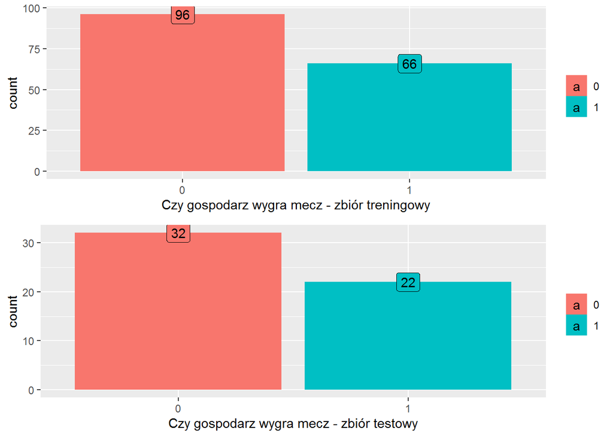

Stosunek meczów wygranych przez gospodarza do pozostałych jest podobny w zbiorze testowym oraz treningowym i wynosi około 2/3.  
Ponadto w przypadku weryfikacji czy podział danych jest poprawny warto spojrzeć na podstawowe satystyki dla obu zbiorów danych:

```r
#Compare median and mean for variables in training and test sets
set.seed(123)
train_stat <- basic_stats_md(train[,-c(1,2)])
test_stat <- basic_stats_md(test[,-c(1,2)])

z <- cbind(train_stat,test_stat[,-1])
colnames(z) <- c("Variable", "Mean - train", "Sd - train", "Median - train", "Mean - test", "Sd - test", "Median - test")
frame_func(z)
```

| Variable | Mean - train | Sd - train | Median - train | Mean - test | Sd - test | Median - test |
| --- | --- | --- | --- | --- | --- | --- |
| Result | 0.41 | 0.49 | 0 | 0.41 | 0.5 | 0 |
| AVGGoals | 0.09 | 0.83 | 0.15 | 0.18 | 0.79 | 0.05 |
| AVGLost | -0.15 | 0.7 | -0.17 | -0.01 | 0.69 | 0.03 |
| AVGShots | 0.53 | 5.16 | 0.53 | 1.21 | 3.95 | 1.58 |
| AVGTarget | 0.37 | 2.07 | 0.2 | 0.56 | 1.67 | 0.4 |
| AVGCorners | 0.24 | 2.48 | 0.29 | 0.61 | 2.03 | 0.49 |
| AVGFouls | -0.58 | 3.54 | -0.25 | 0.04 | 3.83 | -0.59 |
| Overall | 0 | 0.07 | 0 | 0 | 0.07 | 0 |
| PointsDiff | -0.46 | 13.66 | 0 | 0.94 | 13.89 | 0.5 |
| Corners | 10.28 | 3.33 | 10 | 10.17 | 3.56 | 10 |

Wszystkie zmienne mają podobne statystyki dla zbioru testowego oraz treningowego, co pozwala nam przejść do dalszego etapu modelowania. W przypadku niektórych z modeli uczenia maszynowego dane zostaną zestandaryzowane, ze względu na to, że modele te nie radzą sobię w przypadku, gdy wartości przyjmowane przez zmienne znajdują się na różnych skalach.

## 5. Badanie

Jednym z kluczowych aspektów tworzenia modelu uczenia maszynowego jest oszacowanie jego skuteczności wobec nieznanych danych, może zdażyć się, że model będzie niewystarczająco dopasowany z powodu zbyt małej złożonośi lub przetrenowany z powodu zbyt wysokiego stopnia skomplikowania. W celu określenia kompromisu pomiędzy obciążeniem, a wariancją została zastosowana k-krotna kroswalidacja.

### 5.1 Metoda KNN

Przed przystąpieniem do wdrażania metody KNN najważniejsze to dowiedzieć się jaką liczbe sąsiadów należy wziąć pod uwagę, ponadto do parametrów, które były dostrajane zalicza się wartość jaką przyjmuje odległość Minkowskiego oraz jakie jądro algorytmu (kernel) zostanie użyte. Poniżej zostały zaprezentowane macierze dopasowaĹ„ dla przewidywaĹ„ na danych treningowych oraz testowych.

#### Treningowy

| Przewidywanie | Przewidywanie 0 | Wyniki rzeczywiste 1 |
| --- | --- | --- |
| 0 | 96 | 0 |
| 1 | 0 | 66 |

|  | Result |
| --- | --- |
| True Positive | 1 |
| Area Under Curve | 1 |
| Mean Misclassification Error | 0 |
| True Negative | 1 |
| Precision | 1 |

Z wyników dla zbioru treningowego możemy zobaczyć, że model nie pomylił się ani razu, co najprawdopodobniej świadczy o przetrenowaniu i w przypadku, gdy zetknie się z danymi, na których nie był uczony ten wynik będzie już gorszy.

#### Testowy

| Przewidywanie | Przewidywanie 0 | Wyniki rzeczywiste 1 |
| --- | --- | --- |
| 0 | 19 | 13 |
| 1 | 11 | 11 |

|  | Result |
| --- | --- |
| True Positive | 0.59 |
| Area Under Curve | 0.54 |
| Mean Misclassification Error | 0.44 |
| True Negative | 0.50 |
| Precision | 0.63 |

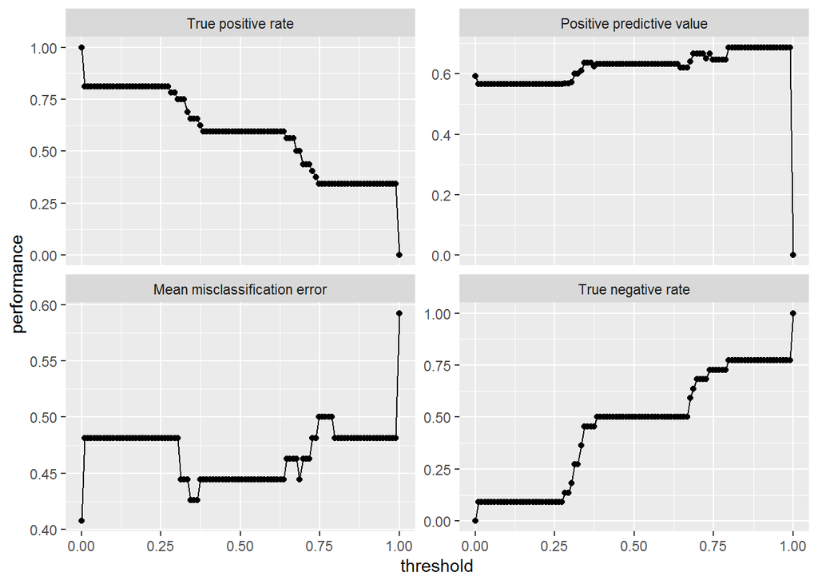

### 5.2 Metoda Naiwny Klasyfikator Bayesa

Przy stosowaniu Naiwnego Klasyfikatora Bayesa występuje znacznie mniejsza liczba parametrów, które mogą zostać zoptymalizowane. Stosując pakiet mlr można przeprowadzić dopasowanie zaledwie dla wygładzania Laplace’a, dla którego został zastosowany przedział od 0 do 10 dla liczb całkowitych.

#### Treningowy

| Przewidywanie | Przewidywanie 0 | Wyniki rzeczywiste 1 |
| --- | --- | --- |
| 0 | 68 | 28 |
| 1 | 17 | 49 |

|  | Result |
| --- | --- |
| True Positive | 0.71 |
| Area Under Curve | 0.78 |
| Mean Misclassification Error | 0.28 |
| True Negative | 0.74 |
| Precision | 0.80 |

Jak możemy zauważyć powyżej w tym przypadku trafność dla zbioru treningowego jest znacznie mniejsza niż dla modelu KNN, jednak nie możemy na podstawie tego wyciągać wniosków. Chociaż przewidywane wyniki odnoszą się do meczów, na których model był trenowany to wyniki nie wydają się być satysfakcjonujące.

#### Testowy

| Przewidywanie | Przewidywanie 0 | Wyniki rzeczywiste 1 |
| --- | --- | --- |
| 0 | 20 | 12 |
| 1 | 11 | 11 |

|  | Result |
| --- | --- |
| True Positive | 0.62 |
| Area Under Curve | 0.62 |
| Mean Misclassification Error | 0.43 |
| True Negative | 0.50 |
| Precision | 0.65 |

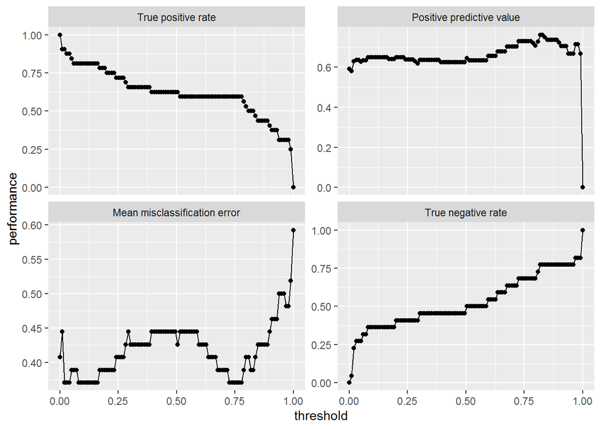

Tym razem średni błąd złego przydziału osiąga najmniejsze wartości w okolicach 75%, 10% oraz 0% co świadczy o tym jak spisuje się dla tego problemu ten model.

### 5.3 Drzewo Decyzyjne

Dla Drzewa Decyzyjnego już większa liczba hiperparametrów została zoptymalizowana. Do dopasowanych parametrów zaliczają się: minimalna liczba obserwacji, które muszą znaleźć się w węźle, aby można było dokonać podziału; minimalna liczba obserwacji w dowolnym węźle; złożoność; maksymalna głębokość dowolnego węzła.

#### Treningowy

| Przewidywanie | Przewidywanie 0 | Wyniki rzeczywiste 1 |
| --- | --- | --- |
| 0 | 86 | 10 |
| 1 | 11 | 55 |

|  | Result |
| --- | --- |
| True Positive | 0.90 |
| Area Under Curve | 0.89 |
| Mean Misclassification Error | 0.13 |
| True Negative | 0.83 |
| Precision | 0.89 |

Dla zbioru treningowego model Drzewa Decyzyjnego poradził sobie znacznie lepiej jeśli chodzi o skuteczność niż Naiwny Klasyfikator Bayesa i chociaż ma wynik słabszy aniżeli KNN to można optymistycznie zapatrywać się na ewentualne praktyczne zastosowanie.

#### Testowy

| Przewidywanie | Przewidywanie 0 | Wyniki rzeczywiste 1 |
| --- | --- | --- |
| 0 | 16 | 16 |
| 1 | 10 | 12 |

|  | Result |
| --- | --- |
| True Positive | 0.50 |
| Area Under Curve | 0.49 |
| Mean Misclassification Error | 0.48 |
| True Negative | 0.55 |
| Precision | 0.62 |

Dla zbioru testowego wyniki niestety nie są zadawalające, w stosunku do poprzednich modeli Drzewo Decyzyjne znacznie gorzej klasyfikuje remis lub przegraną gospodarzy, natomiast jeśli choci o poprawne rozpoznanie meczu, w którym zwycięstwo odniosą gospodarze to poprawił się zaledwie o jedno rozpoznanie.

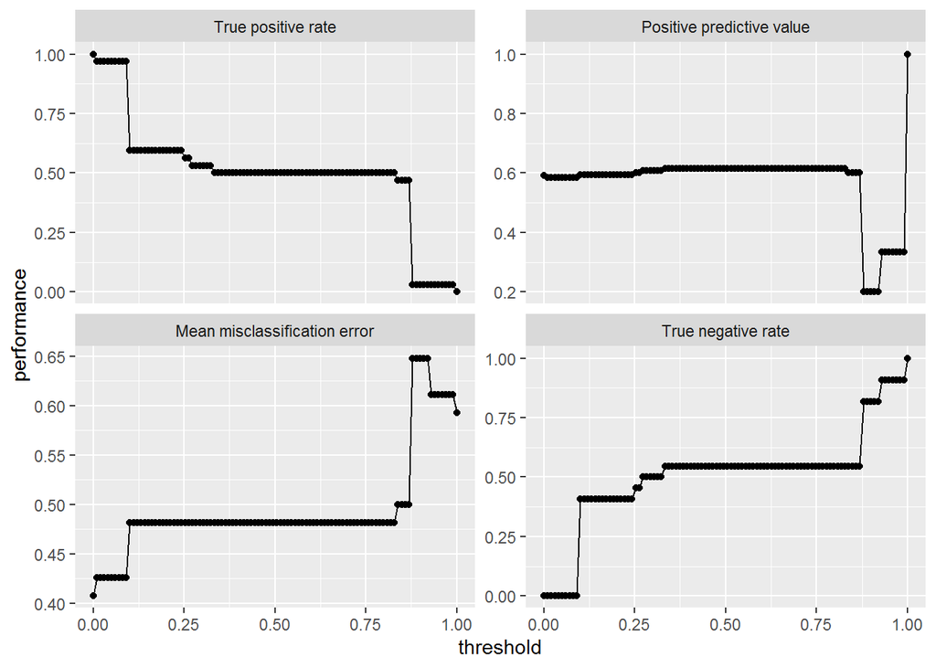

Jak można zauważyć powyżej najmniejszą wartość średni błąd złego przydziału osiąga dla najmniejszych procentów, a więc tak jak w przypadku Naiwnego Klasyfiatora Bayesa można przypuszczać, że model nie sprawdza się zbyt dobrze przy tym problemie.

### 5.4 Random Forest

Kolejnym z modeli jest Random Forest, w kórym następująco hiperparametry zostałe zoptymalizowane: liczba drzew; liczba zmiennych losowana przy podziale każdego węzła; minimalny rozmiar węzłów końcowych; czy należy oceniać istotność zmiennych?; czy pobieranie próbek powinno odbywać się z losowym rozstawieniem danych?; Czy należy obliczyć miarę ważności zmiennych?; Czy współczynnik odległości pomiędzy obserwacjami powinien zostać obliczonyny?

#### Treningowy

| Przewidywanie | Przewidywanie 0 | Wyniki rzeczywiste 1 |
| --- | --- | --- |
| 0 | 96 | 0 |
| 1 | 0 | 66 |

|  | Result |
| --- | --- |
| True Positive | 1 |
| Area Under Curve | 1 |
| Mean Misclassification Error | 0 |
| True Negative | 1 |
| Precision | 1 |

Tak samo jak w przypadku KNN model Random Forest dla zbioru treningowego nie pomylił się ani razu, co najprawdopodobniej świadczy o przetrenowaniu modelu i w przypadku danych, z którymi styczności jeszcze on nie miał wyniki będą znacznie gorsze.

#### Testowy

| Przewidywanie | Przewidywanie 0 | Wyniki rzeczywiste 1 |
| --- | --- | --- |
| 0 | 21 | 11 |
| 1 | 10 | 12 |

|  | Result |
| --- | --- |
| True Positive | 0.66 |
| Area Under Curve | 0.64 |
| Mean Misclassification Error | 0.39 |
| True Negative | 0.55 |
| Precision | 0.68 |

[figure not shown]

Średni błąd złego przydziału również i dla tego modelu osiąga najmniejsze wartości dla punktu granicznego w okolicach 0% co znaczy, że klasyfikując wszystkie przypadki jako remis lub wygraną gości nasz model byłby skuteczniejszy aniżeli teraz. Po zweryfikowaniu skuteczności modelu na zbiorze treningowym dostrajając zaledwie liczbę drzew z jakich składa się model okazuje się, że i tak osiąga on 100% skuteczność co ma związek najprawdopodobniej z tym, że model jest zbyt złożony do tych danych.

## 6. Wnioski

Jak było już wspomniane we wstępie ciężko o modele na tyle skuteczne w tej dziedzinie, że byłoby za ich pomocą możliwe zarabianie na zakładach bukmacherskich. Z powyższej analizy możemy zauważyć, że dla zadanego problemu żaden z modeli nie wykazał satysfakcjonującej skuteczności. Ponadto modele KNN oraz Random Forest wykazały cechy przeuczenia, co najprawdopodobniej ma związek ze zbyt małą ilością danych bądź zbyt dużym poziomem skomplikowania modelu w stosunku do danych. Przy danych dotyczących wydarzeń sportowych możemy wykazać się Feature Engineering, który może przyczynić się do podniesienia skuteczności modeli. W celu ulepszenia badania oraz być może utworzenia modelu, który pozwoliłby na osiąganie zysków w zakładach bukmacherskich powinno się zwiększyć ilość obserwacji, po przez dodanie większej ilości sezonów czy też lig. Ponadto powinno się rozwarzyć dodanie informacji o składach drużyn oraz statystykach piłkarzy, którzy biorą udział w meczu.